# Church Coding Challenge

Devin Harp

```r
churchPoi <- read_parquet('~/DS460/challenge_church_wi23-main/data/parquet/poi.parquet')
devices <- read_parquet('~/DS460/challenge_church_wi23-main/data/parquet/device_type.parquet')
openHours <- read_parquet('~/DS460/challenge_church_wi23-main/data/parquet/open_hours.parquet')
popDay <- read_parquet('~/DS460/challenge_church_wi23-main/data/parquet/popularity_by_day.parquet')
popHour <- read_parquet('~/DS460/challenge_church_wi23-main/data/parquet/popularity_by_hour.parquet')
visitsDay <- read_parquet('~/DS460/challenge_church_wi23-main/data/parquet/visits_by_day.parquet')
visitorCbgs <- read_parquet('~/DS460/challenge_church_wi23-main/data/parquet/visitor_home_cbgs.parquet')
visitorAgg <- read_parquet('~/DS460/challenge_church_wi23-main/data/parquet/visitor_home_aggregation.parquet')
visitorDaytime <- read_parquet('~/DS460/challenge_church_wi23-main/data/parquet/visitor_daytime_cbgs.parquet')
visitorCountry <- read_parquet('~/DS460/challenge_church_wi23-main/data/parquet/visitor_country_of_origin.parquet')
relatedDay <- read_parquet('~/DS460/challenge_church_wi23-main/data/parquet/related_same_day_brand.parquet')
```

*Question 1*

*What differences are there between iPhone and Android users when comparing visits to The Church of Jesus Christ buildings of Latter-day Saints in Utah and Georgia?*

```r
# Code for first question
lds <- churchPoi %>%
  filter(location_name == 'The Church of Jesus Christ of Latter day Saints') %>%
  select(placekey, location_name, region)

ldsDevices <- left_join(lds, devices, by = 'placekey') %>%
  filter(value != 0) %>%
  select(-c('placekey', 'location_name', 'startDate', 'endDate', '__index_level_0__')) %>%
  drop_na()
```

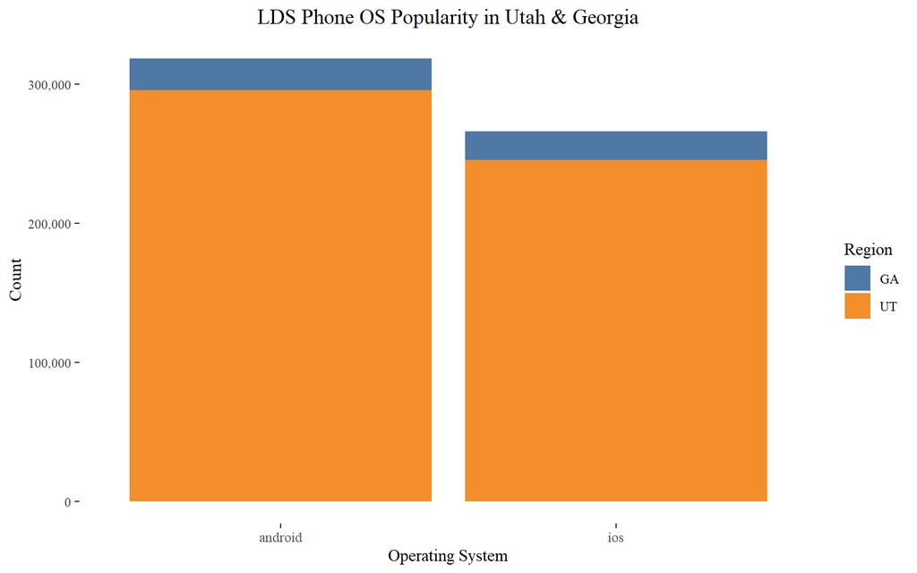

```r
options(scipen = 5)

ggplot(ldsDevices, aes(x = device_type, y = value, fill = region)) +
  geom_col() +
  labs(title = 'LDS Phone OS Popularity in Utah & Georgia', x = 'Operating System', y = 'Count', fill = 'Region') +
  scale_fill_tableau() +
  scale_y_continuous(labels = comma) +
  theme_tufte() +
  theme(plot.title = element_text(hjust = 0.5))
```

```r
pander(head(ldsDevices))
```

Table continues below

[output not shown]

[output not shown]

While the stereotype seems to favor the idea that majority of LDS members prefer IOS compared to their Android counterparts, the truth is actually against the notion. Most members utilize Android as their primary mobile operating system while the proportion between the states is identical in both Android and IOS populations. Because Georgia church membership is miniscule compared to Utah, it will evidently make a small margin within the proportion.

*Question 2*

*What are the hourly usage patterns between The Church of Jesus Christ of Latter-day Saints and the other churches in each state?*

```r
pop <- left_join(churchPoi, popHour, by = 'placekey') %>%
  select(location_name, region, hour, popularity_by_hour) %>%
  mutate(church = ifelse(location_name == 'The Church of Jesus Christ of Latter day Saints', 'LDS', 'Non-LDS')) %>%
  drop_na()
```

```r
popSum <- pop %>%
  group_by(church, region, hour) %>%
  summarise(popTot = sum(popularity_by_hour))
```

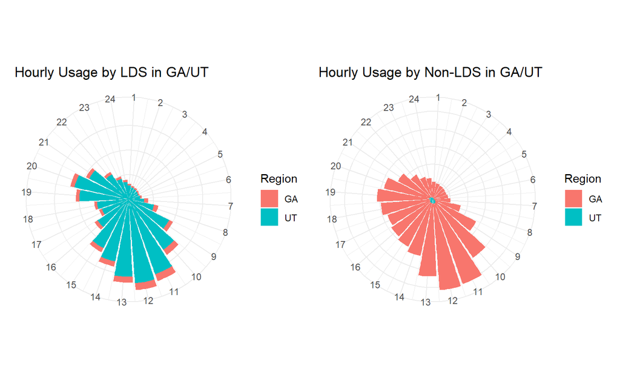

```r
ldsUsage <- ggplot(subset(popSum, church == 'LDS'), aes(x = hour, y = popTot, fill = region)) +
  coord_polar(theta = "x", start = -pi/50) +
  geom_bar(stat = "identity", width = 0.9) +
  scale_x_continuous(breaks = seq(0, 24)) +
  labs(x = 'Hour', y = 'Popularity in Hours Total', title = 'Hourly Usage by LDS in GA/UT', fill = 'Region') +
  theme_bw() +
  theme(panel.border = element_blank(),
        axis.title.x = element_blank(),
        axis.title.y = element_blank(),
        axis.text.y = element_blank(),
        axis.ticks.y = element_blank())

nonLDSusage <- ggplot(subset(popSum, church == 'Non-LDS'), aes(x = hour, y = popTot, fill = region)) +
  coord_polar(theta = "x", start = -pi/50) +
  geom_bar(stat = "identity", width = 0.9) +
  scale_x_continuous(breaks = seq(0, 24)) +
  labs(x = 'Hour', y = 'Popularity in Hours Total', title = 'Hourly Usage by Non-LDS in GA/UT', fill = 'Region') +
  theme_bw() +
  theme(panel.border = element_blank(),
        axis.title.x = element_blank(),
        axis.title.y = element_blank(),
        axis.text.y = element_blank(),
        axis.ticks.y = element_blank())

ldsUsage + nonLDSusage
```

```r
pander(head(popSum))
```

| church | region | hour | popTot |
| --- | --- | --- | --- |
| LDS | GA | 1 | 7221 |
| LDS | GA | 2 | 6690 |
| LDS | GA | 3 | 6471 |
| LDS | GA | 4 | 6357 |
| LDS | GA | 5 | 6201 |
| LDS | GA | 6 | 6744 |

*Question 3*

*What are the differences between brands, those who visit the Church of Jesus Christ of Latter-day Saints and those who visit other churches?*

```r
churchBrands <- left_join(churchPoi, relatedDay, by = "placekey") %>%
  select(location_name, related_same_day_brand, value) %>%
  mutate(church = ifelse(location_name == 'The Church of Jesus Christ of Latter day Saints', 'LDS', 'Non-LDS')) %>%
  filter(related_same_day_brand %in% c("Costco", "Sam's Club")) %>%
  drop_na()
```

```r
churchSum <- churchBrands %>%
  group_by(church, related_same_day_brand) %>%
  summarise(valueTot = sum(value))
```

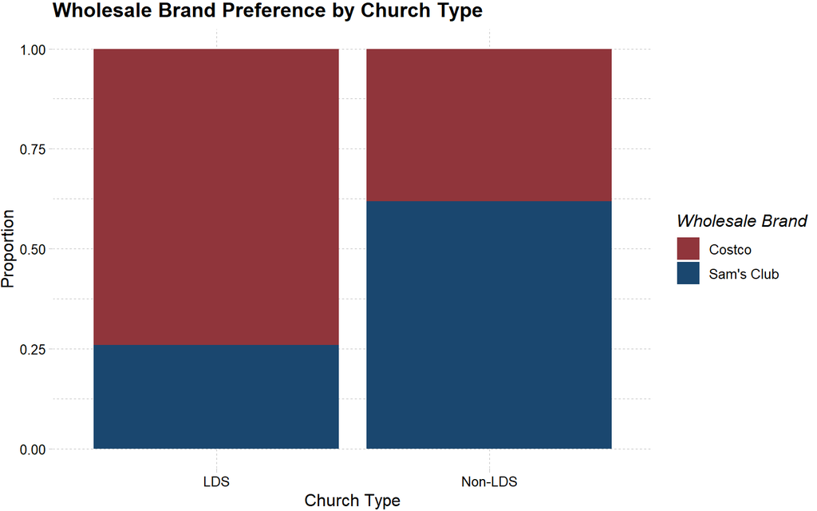

```r
ggplot(churchSum, aes(x = church, y = valueTot, fill = related_same_day_brand)) +
  geom_col(position = 'fill') +
  labs(x = 'Church Type', y = 'Proportion', fill = 'Wholesale Brand', title = 'Wholesale Brand Preference by Church Type') +
  scale_fill_manual(values = c("#90353B", "#1a476f")) +
  theme_pander()
```

```r
pander(head(churchSum))
```

| church | related_same_day_brand | valueTot |
| --- | --- | --- |
| LDS | Costco | 10653 |
| LDS | Sam’s Club | 3723 |
| Non-LDS | Costco | 43566 |
| Non-LDS | Sam’s Club | 70746 |

Wholesale foods are a staple in LDS culture from what I observed. The question remains however - who is the more popular decision, Costco or Sam’s Club? Interestingly, we see Costco make up the majority of the LDS population while it is flipped for the non-LDS group. This could be however due to a lack of Sam’s Club in Utah and Costco in various other religious communities.